# DATA2002 Assignment

Jing Yang 480110301

# 1 Executive Summary

This project aims to explore the *DATA2X02 class survey 2020 (Responses)* dataset and discover how DATA2X02 students’ habits differ based on their genders.

The properties of the survey are discussed in this report. Although the data is a random sample of DATA2002 students, non-response bias, measurement bias and voluntary response bias can occur due to the imperfect survey design, resulting in potentially biased variables in the data.

Furthermore, the poor design of some questions results in generation of invalid data which are responses with different measurement scales. To improve the question design, a suggestions that clearly specify units in questions requesting numeric responses is given.

# 2 Introduction

The dataset used in this analysis `DATA2X02 class survey 2020 (Responses)` is obtained from a voluntary survey designing by DATA20X0 teaching staffs in the University of Sydney. The interviewees of this survey are students enrolling in DATA2X02 in semester 2, 2020. As shown in Table 6.1, there are 20 questions asking about students’ personal information, habits and current status in the survey. These questions contribute to 20 variables in the dataset with an additional variable of time stamp. 174 students have answered the survey before the survey was closed.

```r
knitr::opts_chunk$set(echo = TRUE, message = FALSE, warning = FALSE)
library(tidyverse)
library(janitor)
library(skimr)
library(visdat)
library(gendercodeR)
library(kableExtra)
library(coin)

raw = read_csv("DATA2X02 class survey 2020 (Responses) - Form responses 1.csv")

x = raw %>% janitor::clean_names()
```

# 3 Data Cleaning

The raw data takes the questions in survey as the variable names. It could be problematic to use such long variable names when processing data. Therefore the long questions are changed into some representative words as the variable names in the dataset. The variable names and the corresponding questions can be found in 6.1.

As some of the questions are provided by a text input box to answer, we may get all kinds of responds. One of the variables used in the report which is the “social media” suffer from this issue. Students typing in different letter cases, misspelling the name of media can results in various form of responses for the same social media. For example, for the social media “Instagram”, there are 7 types of typing – “Instagram”, “instragram”, “INSTAGRAM”, “instangram”, “instagram”, “insta” and “ins” in the survey responses. To clean these data, all the misspelling and case sensitive responses for the same media are changed into one spelling “Instagram”. Responses for other media are also cleaned in this way. In addition, there are a few students type in two kinds of media, or type in “NA”. All of these responses are treated as invalid responses and are set to be null value as we cannot classify these responses into one kind of media.

The responses of gender are cleaned by `recode_gender` function in order to deal with the case inconsistency of responses. As the responses numeric responses of the number of hours spent on exercising is well formatted in a reasonable range, no cleaning step is perform with the responses.

```r
colnames(x) = stringr::str_replace(string = colnames(x),
                                   pattern = "what_is_your_",
                                   replacement = "")
colnames(x) = stringr::str_replace(string = colnames(x),
                                   pattern = "on_average_how_many_hours_per_week_did_you_",
                                   replacement = "")

colnames(x)[2] = "covid_test"
colnames(x)[4] = "postcode"
colnames(x)[5] = "dentist"
colnames(x)[6] = "university_work"
colnames(x)[7] = "social_media"
colnames(x)[8] = "dog_or_cat"
colnames(x)[9] = "live_with_parents"
colnames(x)[10] = "exercising"
colnames(x)[12] = "asthma"
colnames(x)[13] = "paid_work"
colnames(x)[14] = "fav_season"
colnames(x)[16] = "height"
colnames(x)[17] = "floss_frequency"
colnames(x)[18] = "glasses"
colnames(x)[20] = "steak_preference"
colnames(x)[21] = "stress_level"


x = x %>% mutate(
  gender = gendercodeR::recode_gender(gender)
)
x
```

```
## # A tibble: 174 x 21
##    timestamp covid_test gender postcode dentist university_work social_media
##    <chr>          <dbl> <chr>     <dbl> <chr>             <dbl> <chr>
##  1 02/09/20…          1 female     2154 Less t…              38 N/A
##  2 02/09/20…          0 male     441000 More t…              40 Bilibili / …
##  3 02/09/20…          0 male       2120 Less t…               3 Facebook
##  4 02/09/20…          5 male     511442 More t…              40 WeChat
##  5 02/09/20…          0 male       2042 More t…               6 Facebook
##  6 02/09/20…          0 male       2046 Betwee…              30 Reddit
##  7 02/09/20…          0 male       2071 Betwee…              36 <NA>
##  8 02/09/20…          0 male       2008 More t…              50 FaceBook
##  9 02/09/20…          1 female     2118 Less t…              40 tiktok
## 10 02/09/20…          0 male       2009 Less t…              20 Reddit
## # … with 164 more rows, and 14 more variables: dog_or_cat <chr>,
## #   live_with_parents <chr>, exercising <dbl>, eye_colour <chr>, asthma <chr>,
## #   paid_work <dbl>, fav_season <chr>, shoe_size <dbl>, height <dbl>,
## #   floss_frequency <chr>, glasses <chr>, dominant_hand <chr>,
## #   steak_preference <chr>, stress_level <dbl>
```

```r
x1 = x %>% mutate(social_media = case_when(
    social_media == "Youtube" ~ "Youtube",
    social_media == "youtube" ~ "Youtube",
    social_media == "YouTube" ~ "Youtube",
    social_media == "Wechat" ~ "Wechat",
    social_media == "WeChat" ~ "Wechat",
    social_media == "wechat" ~ "Wechat",
    social_media == "twitter" ~ "Twitter",
    social_media == "Twitter" ~ "Twitter",
    social_media == "Tiktok" ~ "Tiktok",
    social_media == "TikTok" ~ "Tiktok",
    social_media == "tiktok" ~ "Tiktok",
    social_media == "Tik Tok" ~ "Tiktok",
    social_media == "Snapchat" ~ "Snapchat",
    social_media == "reddit" ~ "Reddit",
    social_media == "Reddit" ~ "Reddit",
    social_media == "Pinterest" ~ "Pinterest",
    social_media == "no" ~ "None",
    social_media == "None" ~ "None",
    social_media == "Messenger" ~ "Messenger",
    social_media == "messenger" ~ "Messenger",
    social_media == "linkedin" ~ "Linkedin",
    social_media == "Instagram" ~ "Instagram",
    social_media == "Instragram" ~ "Instagram",
    social_media == "Instangram" ~ "Instagram",
    social_media == "INSTAGRAM" ~ "Instagram",
    social_media == "instagram" ~ "Instagram",
    social_media == "insta" ~ "Instagram",
    social_media == "ins" ~ "Instagram",
    social_media == "Google+" ~ "Google+",
    social_media == "Facebook Messenger" ~ "Messenger",
    social_media == "Facebook messanger" ~ "Messenger",
    social_media == "facebook" ~ "Facebook",
    social_media == "Facebook" ~ "Facebook",
    social_media == "canvas discussion board" ~ "Canvas discussion board",
    social_media == "Club Penguin" ~ "Club Penguin",
    social_media == "Discord" ~ "Discord",
    social_media =="Ed" ~ "Ed",
    social_media =="bilibili" ~ "Bilibili"
  ) )
```

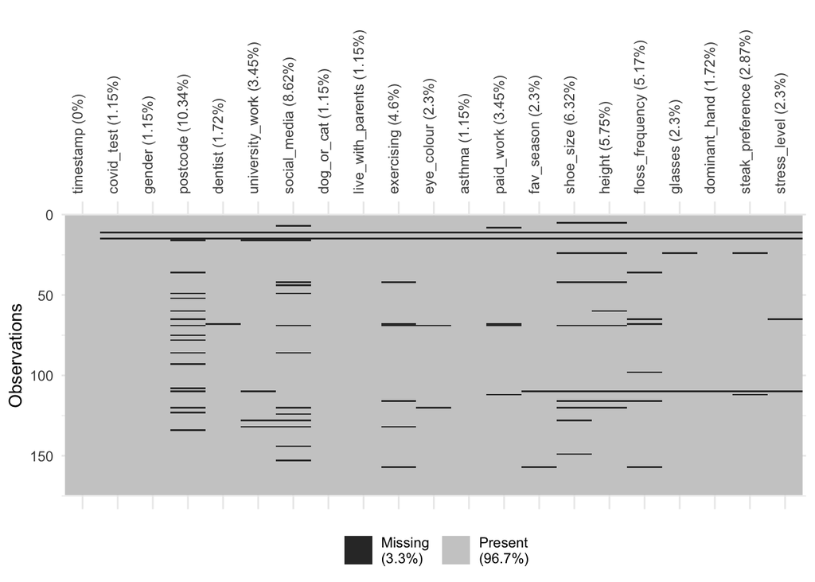

Figure 3.1: Visualising the missingness in the data.

```r
visdat::vis_miss(x)+theme(axis.text.x = element_text(angle = 90))
```

```r
x = x %>% drop_na()
```

# 4 Questions

## 4.1 Is this a random sample of DATA2002 students?

A random sample is a sample chosen from a larger set. Each individual is chosen randomly and entirely by chance, such that each individual has the same probability of being chosen. This is a voluntary survey. No students are forced to answer the survey therefore every DATA2002 student has the same probability to complete the survey at any stage during the sampling process. Thus this is a random sample of DATA2002 students.

## 4.2 What are the potential biases? Which variables are most likely to be subjected to this bias?

The variable “postcode” is the most likely to be subjected to non-response bias. As shown in the missingness plot, postcode contributes to 10.34% of missing values which is the highest missing rate among the whole dataset. Some people may be afraid of personal information leakage thus being unwilling to answer questions related to privacy such as the address and postcode of where they live.

The variable “university work” is the most likely to be subject to measurement bias. Because this survey is published by the course lecturer, some students may think that teaching staffs want their studying hour to be as many as possible, or teaching staffs will be happy about students spending lots of time on this course. To meet this idea or to prove their hard-working, some students may exaggerate the number of hours they spend on university work per week.

Voluntary response bias can occur as this survey is voluntary. Students are self-selected volunteer, resulting in the resulting sample tends to over-represent students who have strong opinions.

## 4.3 Are there any questions that needed improvement to generate useful data?

The questions “How tall are you?” and “What is your shoe size?” should be improved. Height and shoe size should have a natural limited range. However, In the responses of these questions, every extreme values exist and the standard deviation is quite large. This might because students answered questions with numeric responses in different units. For example, for the height response less than 2.3, the unit used is obviously “meter” whereas the unit for height response greater than 100 is centimeter. When specifying shoe sizes, students may refer to different sizing system (UK, US, Europe, Modopoint, etc.).

To improve the questions, units should be specified in the questions so that numeric responses fall in reasonable ranges.The question “How tall are you?” can be changed to “What’s your height in centimeter?” while the question “What is your shoe size?” can be changed to “What is your shoe size in UK sizing system?”.

## 4.4 Does the number of COVID tests follow a Poisson distribution?

```r
x %>% janitor::tabyl(covid_test) %>%
  arrange(covid_test) %>% # arrange in descending order
  gt::gt() %>%
  gt::fmt_percent(columns = c("percent"),
                  decimals = 0) %>%
  gt::tab_source_note("Table: Summary of covid test proportions.")
```

[output not shown]

As shown in Figure 4.1, the peak of the number of times students have been tested for COVID lies to the left with a long tail extending to the right. Therefore the data is significantly right-skewed. A goodness of fit test is performed to test whether these observations follow a Poisson distribution.

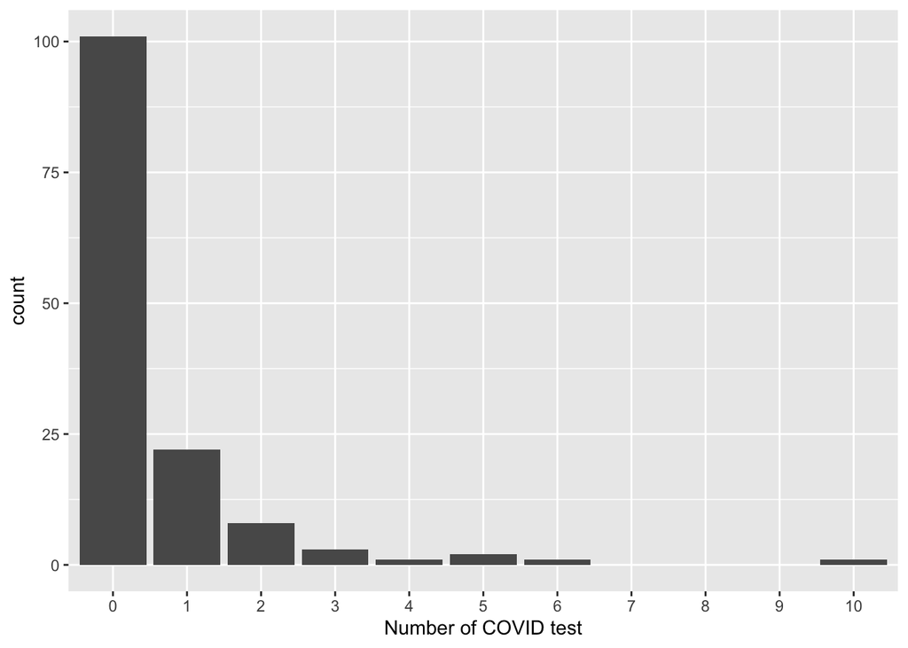

Figure 4.1: Distribution of how many times students have been tested for COVID.

```r
x %>% ggplot() + aes(x = as.factor(covid_test)) +
  geom_bar() + scale_x_discrete(name = "Number of COVID test",limits = c("0","1","2","3","4","5","6","7","8","9","10"))
```

```r
# p1 = x %>% ggplot(aes(x = covid_test)) + geom_bar()
```

There are 11 groups of the number of COVID test:0,1,2,3,4,5,6,7,8,9 and 10. The corresponding observed frequencies are 101, 22,8,3,1,2,1,0,0 and 1. $\lambda$ of the Poisson distribution is estimated to be 0.55.

```r
tab = as.data.frame(table(x$covid_test))
tab$Var1 = as.numeric(as.character(tab$Var1))
var = as.data.frame(c(7,8,9))
fre = as.data.frame(c(0,0,0))
add = cbind(var,fre)
colnames(add) = c("Var1", "Freq")
tab = rbind(tab,add)
tab = tab[order(tab$Var1),]
covid_count = tab$Freq
groups = as.numeric(as.character(tab$Var1))
n=sum(covid_count) # sample size
k = length(covid_count) # number of groups
(lam = sum(covid_count * groups)/n) # estimate the lambda parameter
```

```
## [1] 0.5539568
```

**Hypothesis:** $H_0:$ the data come from a Poisson distribution vs $H_1:$ the data do not come from a Poisson distribution.

**Assumptions:** The expected frequencies, $e_i=np_i \geq 5$. Observations are independent.

The expected frequencies are 79.9, 44.2, 12.3, 2.3, 0.3, 0.03, 0.003, 0, 0, 0 and 0. The expected frequencies $e_3, e_4, e_5, e_6, e_7, e_8, e_9, e_10$ are less than 5, therefore we combine these 8 groups with the number of COVID test greater than 3 to satisfy assumption.

```r
p = dpois(groups, lambda = lam) # obtain the p_i from the Poisson omf
(ey = n*round(p,5)) # calculate the expected frequencies
```

```
##  [1] 79.87913 44.24926 12.25563  2.26292  0.31275  0.03475  0.00278  0.00000
##  [9]  0.00000  0.00000  0.00000
```

```r
ey >= 5 # check assumption e_i >= 5 not all satisfied
```

```
##  [1]  TRUE  TRUE  TRUE FALSE FALSE FALSE FALSE FALSE FALSE FALSE FALSE
```

```r
(eyr = c(ey[1:3],sum(ey[4:11])))
```

```
## [1] 79.87913 44.24926 12.25563  2.61320
```

However, after combining the 11 classes into 4 classes (i.e. $0, 1, 2, \geq 3$), the expected frequency of group $\geq 3$ is still less than 5. Therefore we combine group “2” and group “$\geq 3$”. The final adjacent groups are “0”,“1” and “$\geq 2$”. The corresponding expected frequencies are 79.9, 44.2 and 14.9 while the observed frequencies are 101, 22,16 respectively. The probability of students haven’t been tested for COVID is 0.57, probability of 0.32 for student having 1 COVID test and probability of 0.11 for student having more than 2 COVID test.

```r
(eyr = c(ey[1:2],sum(ey[3:11])))
```

```
## [1] 79.87913 44.24926 14.86883
```

```r
(yr = c(covid_count[1:2],sum(covid_count[3:11])))
```

```
## [1] 101  22  16
```

```r
(pr = c(p[1:2],sum(p[3:8])))
```

```
## [1] 0.5746714 0.3183432 0.1069853
```

[figure not shown]

Figure 4.2: Distribution of the observed and expected frequencies for different number of COVID tests

```r
xr = c("0","1",">=3") # group labels
par(mfrow=c(1,2), cex = 1.5)
data = data.frame("xr" = xr, "yr" = yr,"eyr" =eyr)

times = c("0","1",">=3")
data = data %>%
  mutate(
    xr = factor(xr, levels = times)
  )

ob = ggplot(data, aes(x=xr,y=yr))+geom_bar(stat="identity")+labs(x="Number of COVID tests", y="Observed frequency")
ex = ggplot(data, aes(x=xr,y=eyr))+geom_bar(stat="identity")+labs(x="Number of COVID tests", y="Expected frequency")
gridExtra::grid.arrange(ob, ex, ncol = 2)
```

The expected frequencies are all greater than 5 so that the assumption $e_i \geq 5$ is met. As this is a random sampling research, the assumption of independence is met.

**Test statistic:**$T=\sum^k_{i=1}\frac{(Y_i-np_i)^2}{np_i}$.

**Observed test statistic:** $t_0=16.86$

```r
kr = length(yr) #number of combined classes
(t0 = sum((yr - eyr)^2/eyr))
```

```
## [1] 16.85793
```

```r
(pval = 1 - pchisq(t0, df = kr-1-1))
```

```
## [1] 4.028469e-05
```

## 4.5 Perform other hypothesis tests.

### 4.5.1 Are men more likely to spend time on exercising compared to women?

From Figure 4.3 , the left boxplot show all observations of exercising hours including outliers while the right boxplot removes the outliers. The right plot aims to shows the patterns within boxes more clearly. As shown in the boxplot, both mean and median of exercising hour are greater for males compared to females.

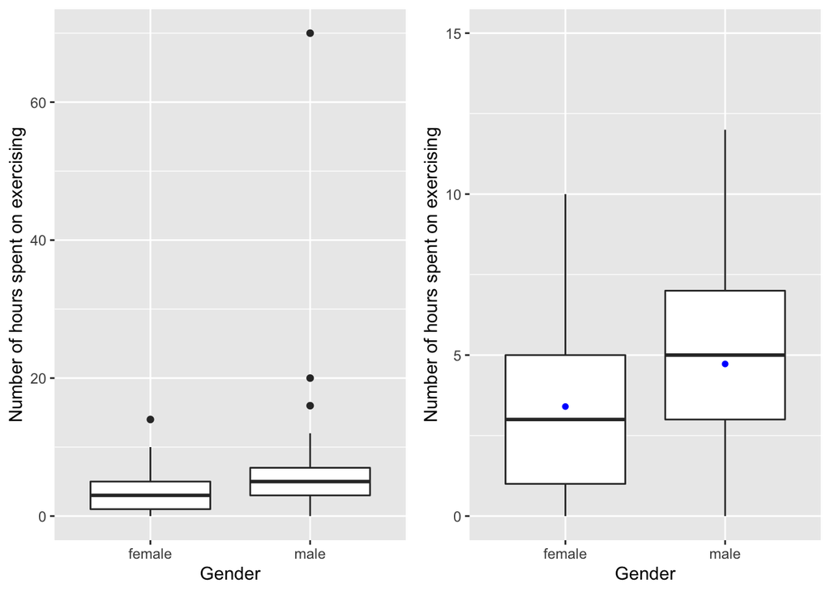

Figure 4.3: Number of hours spent on exercising by different genders. The left boxplot shows all data including outliers while the right plot removes outliers. The means are shown by the blue dots in the right plots.

```r
x_gender = x %>% filter(gender!="non-binary")

p1 = x_gender %>% ggplot() +
  aes(y = as.factor(gender), x = exercising) +
  geom_boxplot() +
  labs(y = "Gender", x = "Number of hours spent on exercising" ) +
  theme(legend.position = "none") + coord_flip()

p2 = x_gender %>% ggplot() +
  aes(y = as.factor(gender), x = exercising) +
  geom_boxplot(outlier.shape=NA) +
  labs(y = "Gender", x = "Number of hours spent on exercising" ) +
  theme(legend.position = "none") + xlim(0, 15)+stat_summary(fun.y=mean, geom="point", shape=20, size=2, color="blue", fill="red") + coord_flip()

gridExtra::grid.arrange(p1, p2, ncol = 2)
```

```r
dat = x_gender%>% select(gender,exercising)
dat$gender = as.factor(dat$gender)

sum = dat %>% group_by(gender) %>%
      summarise(Mean = mean(exercising),
      Median = median(exercising),
      SD = sd(exercising),
      Variance = var(exercising),
      n = n())

colnames(sum)=c("Gender","Mean","Median","SD","Variance","Number of students")
knitr::kable(sum,digits = 1, align="cccccc",caption = "Statistics of number of hours spent on exercising by different genders.") %>% kable_paper(full_width = F, position = "float_right",html_font = "Cambria")
```

Table 4.1: Statistics of number of hours spent on exercising by different genders.

| Gender | Mean | Median | SD | Variance | Number of students |
| --- | --- | --- | --- | --- | --- |
| female | 3.4 | 3 | 2.9 | 8.4 | 46 |
| male | 5.7 | 5 | 7.6 | 57.5 | 92 |

Two hypothesis tests applying two-sample t-test and Mood’s median test are performed to validate whether means and medians of exercising hour for different genders are different.

#### 4.5.1.1 Two-sample t-test

The variances of two samples are different, violating the assumption of regular two-sample t-test of equal population variances. Thus, in stead of a regular two-sample t-test, we apply the Welch two-sample t-test which does not assume equal population variances.

**Hypothesis:** $H_0:$ Gender and number of hours spent on exercising are independent $(\mu_F=\mu_M)$ **vs** $H_1:$ Gender and number of hours spent on exercising are related (Not all equalities hold).

**Assumptions:** $X_1,...,X_{n_x}$ are iid $N(\mu_X,\sigma^2),$ $Y_1,...,Y_{n_y}$ are iid $N(\mu_Y,\sigma^2)$ and $X_i$’s are independent of $Y_i$’s.

This is a random sample of DATA2002 students therefore observations are supposed to be independent and identically distributed. As such, all assumptions are fulfilled.

```r
female = x %>% filter(gender == "female") %>% select(exercising)
male = x %>% filter(gender == "male") %>% select(exercising)
t.test(male,female, alternative = "two.sided")
```

```
##
##  Welch Two Sample t-test
##
## data:  male and female
## t = 2.5845, df = 129.47, p-value = 0.01086
## alternative hypothesis: true difference in means is not equal to 0
## 95 percent confidence interval:
##  0.5442072 4.0970971
## sample estimates:
## mean of x mean of y
##  5.722826  3.402174
```

**Decision:** As p-value is small than 0.05, we reject $H_0$ and conclude that the mean number of hours spent on exercising by males is different from that for females. Therefore gender and number of hours spent in exercising is related.

#### 4.5.1.2 Median test

A two-sample Mood’s median test is applied to test whether the medians of exercising hours for males and females differ.

**Hypothesis:** $H_0: \widetilde{x}= \widetilde{y}$ **vs** $H_1: \widetilde{x}\neq \widetilde{y}$.

**Assumptions:** $X_1,...,X_{n_x}$ are iid $N(\mu_X,\sigma^2),$ $Y_1,...,Y_{n_y}$ are iid $N(\mu_Y,\sigma^2)$ and $X_i$’s are independent of $Y_i$’s.

This is a random sample of DATA2002 students therefore observations are supposed to be independent and identically distributed. As such, all assumptions are fulfilled.

Under $H_0,T$~$T_{(r-1)(c-1)}$ where r is the number of rows and c is the number of columns in contingency table,

**Test statistics:**

$T=\sum{\frac{(O-E)}{E}}=-3.0066$, where and O is the observed frequencies E is the expected frequencies in the contingency table.

**P-value:** $P(t_{(r-1)(c-1)}\geq |-3|)=0.002642$

```r
median_test(exercising ~ gender, data=dat)
```

```
##
##  Asymptotic Two-Sample Brown-Mood Median Test
##
## data:  exercising by gender (female, male)
## Z = -3.0066, p-value = 0.002642
## alternative hypothesis: true mu is not equal to 0
```

**Decision:** As p-value is less than 0.05, we reject $H_0$ and conclude that the median exercising hours spent by males is different from that for females. Therefore exercising hour is related to gender.

As discussed above by the two hypotheses, both mean and median exercising hours for different genders do not equal. Due to the existence of outliers, the two-sample t-test testing means may be affected by the extreme values while the Mood’s median test is more robust to outliers and the shapes of the population distribution.Therefore although two-sample t-test and two-sample Mood’s median test give the same result that exercising hour is related to gender, we regard the median test as the more reliable test compared to t-test in this case.

### 4.5.2 Are gender and favorite social media related?

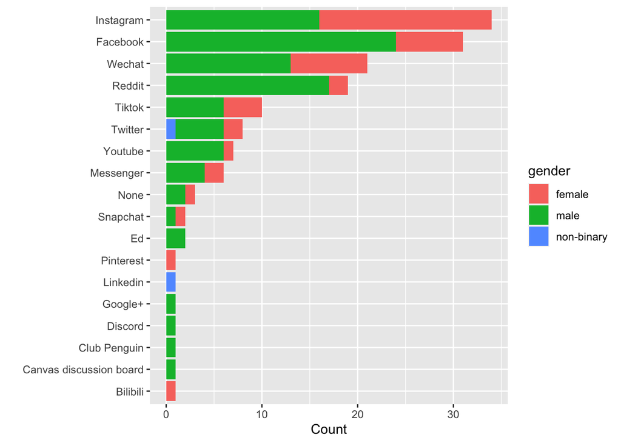

Figure 4.4: DATA2002 students’ favorite social media

```r
media_f = as.data.frame(table(x1$social_media))
sort = arrange(media_f, Freq)
x1 %>% ggplot() +
  aes(y = social_media,fill = gender, stat = "count")   +
  geom_bar() +
  scale_y_discrete(name=" ", limits=as.character(sort$Var1)) +
  labs(y = "", x = "Count")+theme(plot.title = element_text(hjust = 0.5))
```

To perform a hypothesis testing, a contingency table with a size of $3 \times 18$ is obtained. From Table 4.2, many expected frequencies in the contingency table are less than 5, obeying the assumption of Chi-square test. In addition, it is difficult to compute such a large contingency table by Fisher’s exact test. Thus, we use an alternative method **Yates’ continuity correction** to test in these small samples.

```r
y.mat1 = table(x1$social_media,x1$gender)

r1 = nrow(y.mat1)
c1 = ncol(y.mat1)
yr1 = apply(y.mat1,1,sum) #rowSums(y.mat1)
yc1 = apply(y.mat1,2,sum) #colSums(y.mat1)
yr.mat1 = matrix(yr1, r1, c1, byrow = FALSE)
yc.mat1 = matrix(yc1, r1, c1, byrow = TRUE)
ey.mat1 = yr.mat1 * yc.mat1 / sum(y.mat1)
rownames(ey.mat1)=rownames(y.mat1)
colnames(ey.mat1) = colnames(y.mat1)
knitr::kable(ey.mat1, align = "lccc",caption ="Contingency table",digits = 1) %>%
  kable_classic(full_width = F, html_font = "Cambria",position = "float_right")
```

Table 4.2: Contingency table

|  | female | male | non-binary |
| --- | --- | --- | --- |
| Bilibili | 0.3 | 0.7 | 0.0 |
| Canvas discussion board | 0.3 | 0.7 | 0.0 |
| Club Penguin | 0.3 | 0.7 | 0.0 |
| Discord | 0.3 | 0.7 | 0.0 |
| Ed | 0.6 | 1.3 | 0.0 |
| Facebook | 9.9 | 20.7 | 0.4 |
| Google+ | 0.3 | 0.7 | 0.0 |
| Instagram | 10.9 | 22.7 | 0.5 |
| Linkedin | 0.3 | 0.7 | 0.0 |
| Messenger | 1.9 | 4.0 | 0.1 |
| None | 1.0 | 2.0 | 0.0 |
| Pinterest | 0.3 | 0.7 | 0.0 |
| Reddit | 6.1 | 12.7 | 0.3 |
| Snapchat | 0.6 | 1.3 | 0.0 |
| Tiktok | 3.2 | 6.7 | 0.1 |
| Twitter | 2.6 | 5.3 | 0.1 |
| Wechat | 6.7 | 14.0 | 0.3 |
| Youtube | 2.2 | 4.7 | 0.1 |

**Hypothesis:** $H_0:$ gender and favorite social media are independent ($p_{ij}=p_ip_j$ where $i=1,2,3$ and $j=1,2,3,...,18$) **vs** $H_1:$ gender and favorite social media are related (not all equalities hold).

**Assumptions:** Observations are independent.

As data is obtained form random sampling, we suppose the observations are independent. Thus the only assumption is met.

Under $H_0$, $T$ ~ $\sum^2_{i=1}\sum^2_{j=1}{\frac{(|Y_{ij}-e_{ij}|-0.5)^2}{e_{ij}}}$

```r
res.yates1 = (abs(y.mat1 - ey.mat1)-0.5)^2/ey.mat1
(t0 = sum(res.yates1))
```

```
## [1] 165.4046
```

```r
pchisq(t0,1,lower.tail=FALSE)
```

```
## [1] 7.4634e-38
```

**Decision:** As p-value < 0.05, we reject $H_0$. Therefore gender and favorite social media are related.

# 5 Conclusion

Despite a random sample of DATA2002 students, the data can surfer from non-response bias, measurement bias and voluntary response bias. These bias can subject to variables postcode of where student live and the number of hours student spend on university work.

The survey questions asking students’ height and shoe size need to be improved. As the units of requested numeric responses are not specified in the questions, students gave their answers in different measurement scales, resulting in unreasonable ranges of responses. The units used for responses should be clarified in the questions so that numeric responses fall in reasonable ranges.

Although the data does provide valid evidence of the above research questions, some limitations exist with the research design. The survey is distributed online without presenting questions to students face-to-face, and as discussed above some of the questions are not clear enough in text. As such, without orally explaining the questions or stating detail in text, respondents can have different interpretations of the questions. On the other hand, the existence of missingness reflects that some questions are frequently be ignored or left unanswered in this survey. This results in abundant loss of valid data.

There are several potential solutions for the existing limitations. First, it could be helpful to pose a video explaining each question prior to the survey, otherwise, clear explanation should be involved in the survey by text. Second, making answering the question required can also decrease the rate of missingness. Third, shortening the length of survey can also help getting higher completion rates.

# 6 Appendix

```r
detail = data.frame(Position=1:21, "Survey question"=colnames(raw),"Variable name"=colnames(x))
colnames(detail)=c("Position","Survey question","Variable name")
knitr::kable(detail,align="cll",caption = "Table of survey questions and corresponding variable names for data processing.") %>% kable_paper(full_width = F,html_font = "Cambria")
```

Table 6.1: Table of survey questions and corresponding variable names for data processing.

| Position | Survey question | Variable name |
| --- | --- | --- |
| 1 | Timestamp | timestamp |
| 2 | How many times have you been tested for COVID? | covid_test |
| 3 | Gender | gender |
| 4 | Postcode of where you live during semester | postcode |
| 5 | How long has it been since you last went to the dentist? | dentist |
| 6 | On average, how many hours per week did you spend on university work last semester? | university_work |
| 7 | What is your favourite social media platform? | social_media |
| 8 | Did you have a dog or a cat when you were a child? | dog_or_cat |
| 9 | Do you currently live with your parents? | live_with_parents |
| 10 | How many hours a week do you spend exercising? | exercising |
| 11 | What is your eye colour? | eye_colour |
| 12 | Do you have asthma? | asthma |
| 13 | On average, how many hours per week did you work in paid employment in semester 1? | paid_work |
| 14 | What is your favourite season of the year? | fav_season |
| 15 | What is your shoe size? | shoe_size |
| 16 | How tall are you? | height |
| 17 | How often do you floss your teeth? | floss_frequency |
| 18 | Do you wear glasses or contacts? | glasses |
| 19 | What is your dominant hand? | dominant_hand |
| 20 | How do you like your steak cooked? | steak_preference |
| 21 | On a scale from 0 to 10, please indicate how stressed you have felt in the past week. | stress_level |

# 7 References

- Beaudry J, Emily Kothe, Felix Singleton Thorn and Rhydwyn McGuire (2020). gendercodeR: Recodes Sex/Gender Descriptions Into A Standard Set. R package version 0.0.0.9000. https://github.com/ropenscilabs/gendercoder
- Firke S (2020). janitor: Simple Tools for Examining and Cleaning Dirty Data. R package version 2.0.1. https://CRAN.R-project.org/package=janitor
- Iannone R, Joe Cheng and Barret Schloerke (2020). gt: Easily Create Presentation-Ready Display Tables. R package version 0.2.2. https://CRAN.R-project.org/package=gt
- R Core Team (2020). R: A language and environment for statistical computing. R Foundation for Statistical Computing, Vienna, Austria. https://www.R-project.org/.
- Tierney N (2017). “visdat: Visualising Whole Data Frames.” *JOSS*, *2*(16), 355. doi: 10.21105/joss.00355
- Waring E, Michael Quinn, Amelia McNamara, Eduardo Arino de la Rubia, Hao Zhu and Shannon Ellis (2020). skimr: Compact and Flexible Summaries of Data. R package version 2.1.2. https://CRAN.R-project.org/package=skimr
- Wickham H et al., (2019). Welcome to the tidyverse. Journal of Open Source Software, 4(43), 1686, doi: 10.21105/joss.01686
- Hao Zhu, Thomas Travison, Timothy Tsai, Will Beasley, Yihui Xie and GuangChuang Yu (2020). kableExtra: Construct Complex Table with ‘kable’ and Pipe Syntax. R package version 1.2.1. https://cran.r-project.org
- Torsten Hothorn, Henric Winell, Kurt Hornik, Mark A. van de Wiel and Achim Zeileis (2019). coin: Conditional Inference Procedures in a Permutation Test Framework. R package version 1.3.1. https://cran.r-project.org